# Reproducible Research Peer Assignment 1

Dhruv Mishra

```r
library(lattice)
library(plyr)
library(dplyr)
```

## Load Data into Workspace

It is assumed that the zip file is present in the workspace directory (hence the working directory is not being set). This markdown file is written in R Markdown v2.

```r
unzip(zipfile="activity.zip", exdir=getwd());
activity <- read.csv(file="activity.csv", header=TRUE, stringsAsFactors=F, quote="\"")
```

##### Convert date field to class type Date.

```r
activity <- mutate(activity, date = as.Date(date, "%Y-%m-%d"))
```

## What is mean total number of steps taken per day?

Get the vector containing the number of steps taken on each day. Plot the histogram for this data.

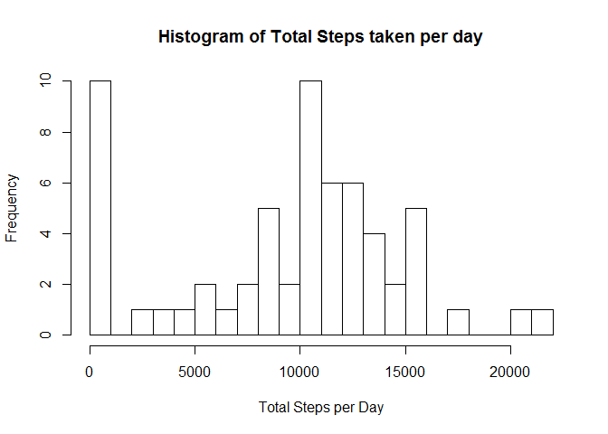

```r
step_num <- sapply(split(activity$steps, activity$date), sum, na.rm=TRUE)
hist(step_num, xlab="Total Steps per Day", ylab="Frequency", main="Histogram of Total Steps taken per day", breaks=25)
```

```r
mean <- format(round(mean(sapply(split(activity$steps, activity$date), sum), na.rm=TRUE),3),nsmall=2)
median <- median(sapply(split(activity$steps, activity$date), sum), na.rm=TRUE)
```

The mean is **10766.19** and the median is **10765**.

## What is the average daily activity pattern?

### Time series plot of the 5-minute interval (x-axis) and the average number of steps taken, averaged across all days (y-axis)

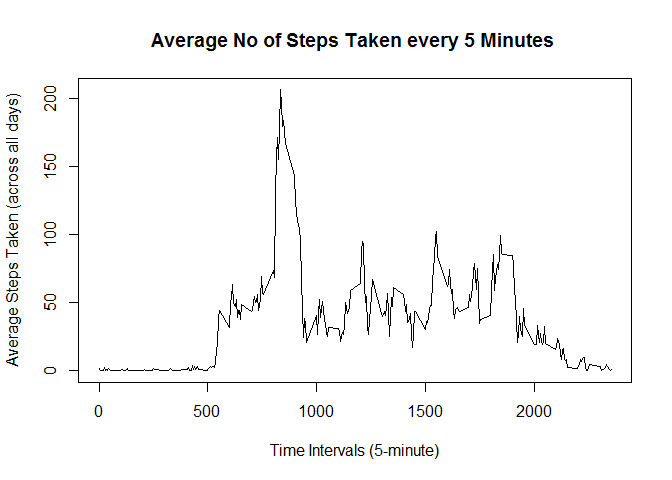

```r
by_interval <- group_by(activity, interval)
avg_steps <- summarise(group_by, steps.in.interval  = mean(steps, na.rm = TRUE))
with(avg_steps,
     plot(interval, steps.in.interval, type="l",
          xlab="Time Intervals (5-minute)",
          ylab="Average Steps Taken (across all days)",
          main="Average No of Steps Taken every 5 Minutes "))
```

```r
max_steps_interval <- avg_steps[which.max(avg_steps$steps.in.interval), ]$interval
max_steps <- max(avg_steps$steps.in.interval)
```

```r
total_missing_val <- sum(is.na(activity))
```

**2304** values are missing.

### Devise a strategy for filling in all of the missing values.

A good strategy can be replacing the missing values with the mean for the corresponding 5-minute interval.